# Rapport statistique

MUTAMU TONY DASSIN

15/11/2021

Installation des packages “tidyverse” et “tidytuesdayR”

install.packages(“tidytuesdayR”) install.packages(“tidyverse”)

Lancement de la library “tidyverse” et “tidytuesdayR” et récupération des données

```r
#install.packages("tidyverse")
#install.packages("tidytuesdayR")
library(tidyverse)
plastics <- readr::read_csv('https://raw.githubusercontent.com/rfordatascience/tidytuesday/master/data/2021/2021-01-26/plastics.csv')
```

# Code de fusion des bases données

library(fs)

files_2020 <- fs::dir_ls(“2020 BFFP National Data Results”) %>% str_subset(“csv”)

files_2019 <- fs::dir_ls(“2019 Brand Audit Appendix _ Results by Country/Countries”) %>% str_subset(“csv”)

data_2020 <- files_2020 %>% map_dfr(read_csv, col_types = cols( Country = col_character(), Parent_company = col_character(), Empty = col_double(), HDPE = col_double(), LDPE = col_double(), O = col_double(), PET = col_double(), PP = col_double(), PS = col_double(), PVC = col_double(), Grand_Total = col_character(), num_events = col_double(), volunteers = col_double() )) %>% mutate(year = 2020, .after = Country) %>% mutate(Grand_Total = parse_number(Grand_Total)) %>% janitor::clean_names()

data_2019 <- files_2019 %>% set_names(str_replace(., “.*/[.].*”, “\1”)) %>% map_dfr(read_csv, .id = “country”, col_types = cols( Country = col_character(), Parent_company = col_character(), Empty = col_double(), HDPE = col_double(), LDPE = col_double(), O = col_double(), PET = col_double(), PP = col_double(), PS = col_double(), PVC = col_double(), Grand_Total = col_double(), num_events = col_double(), volunteers = col_double() )) %>% select(country, everything()) %>% mutate(year = 2019, .after = country) %>% janitor::clean_names() %>% mutate(pp = if_else(is.na(pp_2), pp, pp_2 + pp), ps = if_else(is.na(ps_2), ps, ps + ps_2)) %>% rename(parent_company = parent_co_final, num_events = number_of_events, volunteers= number_of_volunteers) %>% select(-ps_2, -pp_2)

combo_data <- bind_rows(data_2019, data_2020)

combo_data %>% write_csv(“2021/2021-01-26/plastics.csv”)

- Nettoyage de la base de données

Omission des valeurs manquantes de la base de données

- Présentation des variables explicatives

Renommage des variables non-explicites

```r
plastics <- plastics %>%
  rename( Pays = country ,Année = year, Source_plastic = parent_company , Cat_vide= empty, Cat_autre= o ,Polyester= pet , Polypropylene = pp ,Polystyrene = ps , Nombre_even = num_events , Volontaires = volunteers )
```

```r
plastique <- na.omit(plastics)
```

- Questions

Statistiques descriptives

```r
summary(plastique)
```

```
##      Pays               Année      Source_plastic        Cat_vide
##  Length:6826        Min.   :2019   Length:6826        Min.   :   0.0000
##  Class :character   1st Qu.:2019   Class :character   1st Qu.:   0.0000
##  Mode  :character   Median :2020   Mode  :character   Median :   0.0000
##                     Mean   :2020                      Mean   :   0.6109
##                     3rd Qu.:2020                      3rd Qu.:   0.0000
##                     Max.   :2020                      Max.   :2208.0000
##       hdpe               ldpe            Cat_autre         Polyester
##  Min.   :   0.000   Min.   :    0.00   Min.   :    0.0   Min.   :    0.00
##  1st Qu.:   0.000   1st Qu.:    0.00   1st Qu.:    0.0   1st Qu.:    0.00
##  Median :   0.000   Median :    0.00   Median :    0.0   Median :    0.00
##  Mean   :   4.147   Mean   :   13.09   Mean   :   36.4   Mean   :   26.43
##  3rd Qu.:   0.000   3rd Qu.:    0.00   3rd Qu.:    2.0   3rd Qu.:    1.00
##  Max.   :3728.000   Max.   :11700.00   Max.   :28055.0   Max.   :36226.00
##  Polypropylene      Polystyrene            pvc            grand_total
##  Min.   :   0.00   Min.   :   0.000   Min.   :  0.0000   Min.   :    0.00
##  1st Qu.:   0.00   1st Qu.:   0.000   1st Qu.:  0.0000   1st Qu.:    1.00
##  Median :   0.00   Median :   0.000   Median :  0.0000   Median :    2.00
##  Mean   :  10.19   Mean   :   2.197   Mean   :  0.3857   Mean   :   93.45
##  3rd Qu.:   0.00   3rd Qu.:   0.000   3rd Qu.:  0.0000   3rd Qu.:    8.00
##  Max.   :6046.00   Max.   :1390.000   Max.   :622.0000   Max.   :80570.00
##   Nombre_even      Volontaires
##  Min.   :  1.00   Min.   :   3
##  1st Qu.:  4.00   1st Qu.: 190
##  Median : 17.00   Median : 400
##  Mean   : 24.11   Mean   :1477
##  3rd Qu.: 32.00   3rd Qu.:2099
##  Max.   :134.00   Max.   :6850
```

```r
names(plastique)
```

```
##  [1] "Pays"           "Année"          "Source_plastic" "Cat_vide"
##  [5] "hdpe"           "ldpe"           "Cat_autre"      "Polyester"
##  [9] "Polypropylene"  "Polystyrene"    "pvc"            "grand_total"
## [13] "Nombre_even"    "Volontaires"
```

```r
dim(plastique)
```

```
## [1] 6826   14
```

- Pour chaque type de plastique , quel est le pays qui en pollue le plus ?

Lancement de la library “ggplot2”

```r
library(ggplot2)
```

ldpe

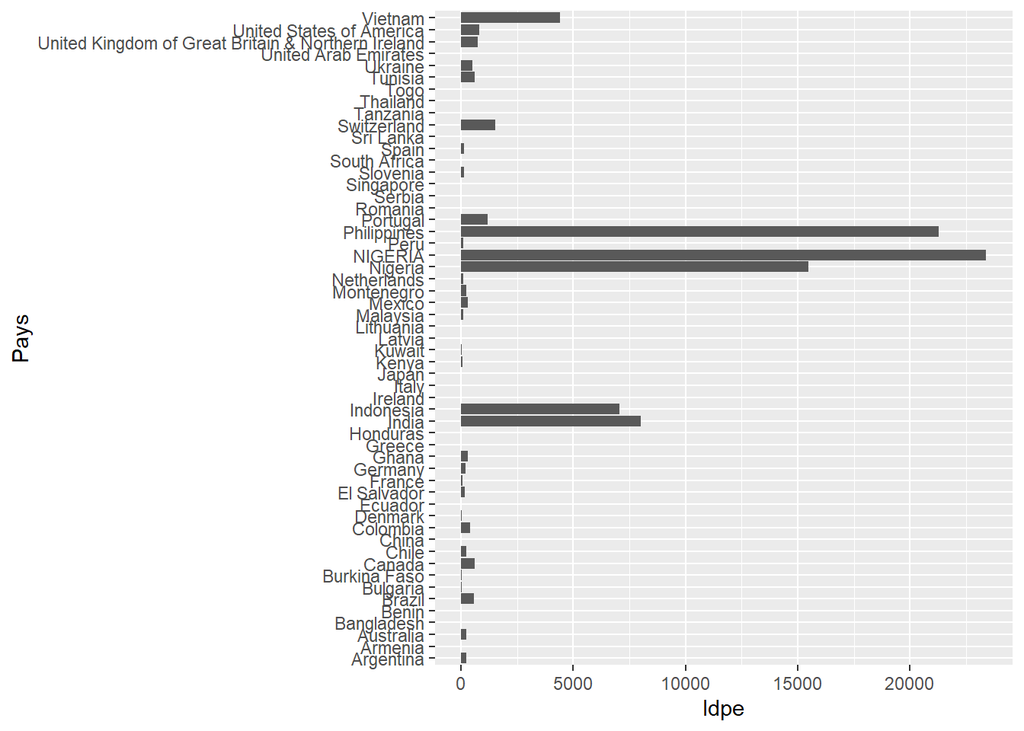

```r
plastique %>%
  group_by(Pays) %>%
  ggplot()+
  aes(x= ldpe, y=Pays)+
  geom_bar(stat='identity')
```

Polyester

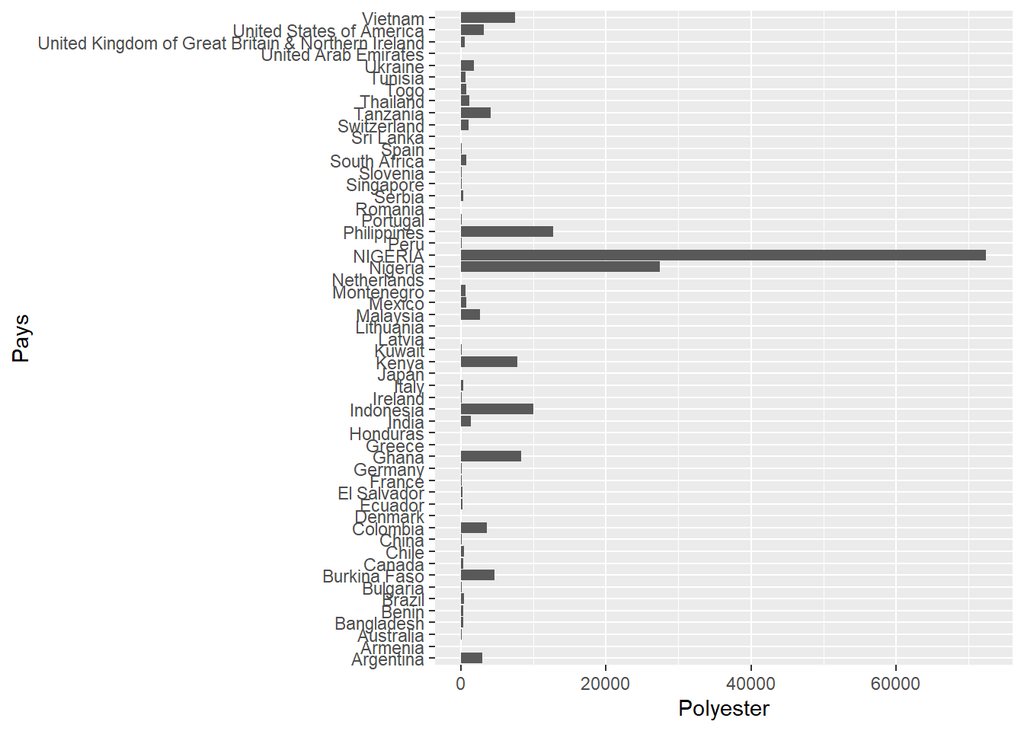

```r
plastique %>%
  group_by(Pays) %>%
  ggplot()+
  aes(x= Polyester , y=Pays)+
  geom_bar(stat='identity')
```

Polypropylene

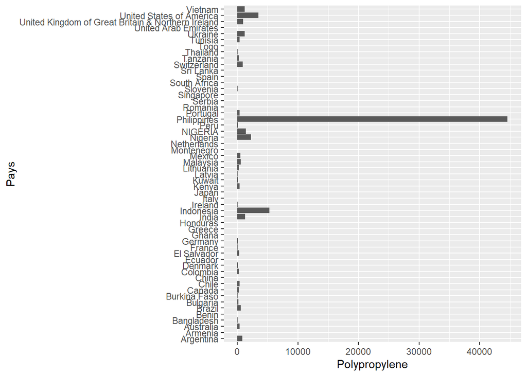

```r
plastique %>%
  group_by(Pays) %>%
  ggplot()+
  aes(x= Polypropylene , y=Pays)+
  geom_bar(stat='identity')
```

Polystyrene

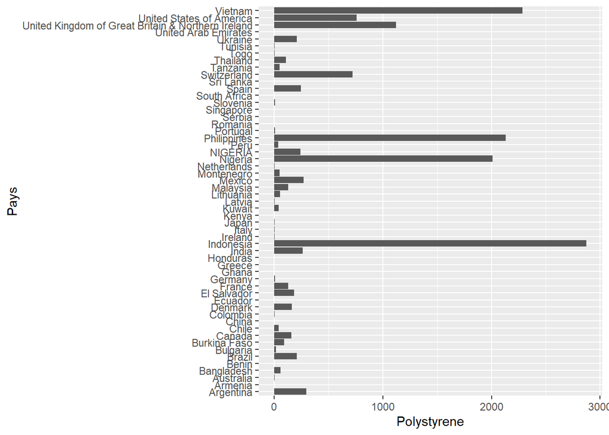

```r
plastique %>%
  group_by(Pays) %>%
  ggplot()+
  aes(x= Polystyrene , y=Pays)+
  geom_bar(stat='identity')
```

pvc

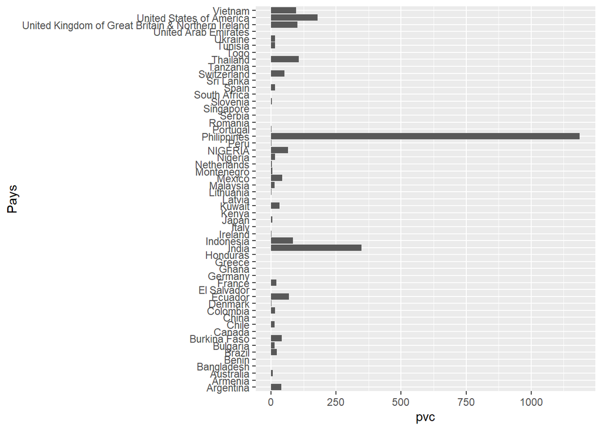

```r
plastique %>%
  group_by(Pays) %>%
  ggplot()+
  aes(x= pvc , y=Pays)+
  geom_bar(stat='identity')
```

Quel pays pollue le plus en plastique en générale en 2019 ?

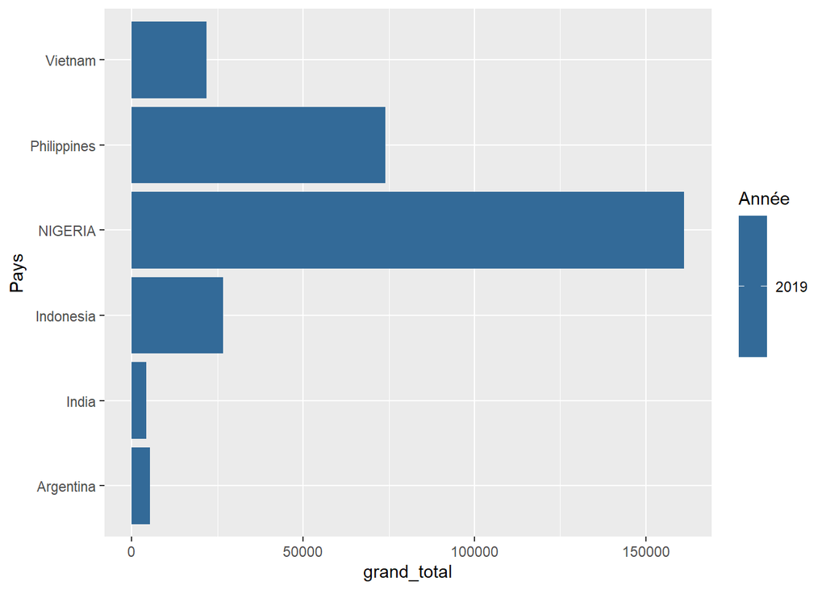

```r
plastique %>%
  filter(Année=="2019") %>%
  group_by(Pays) %>%
  ggplot()+
  aes(x= grand_total, y=Pays)+
  geom_bar(stat='identity', aes(fill= Année))
```

Quel pays pollue le plus en plastique en générale en 2020 ?

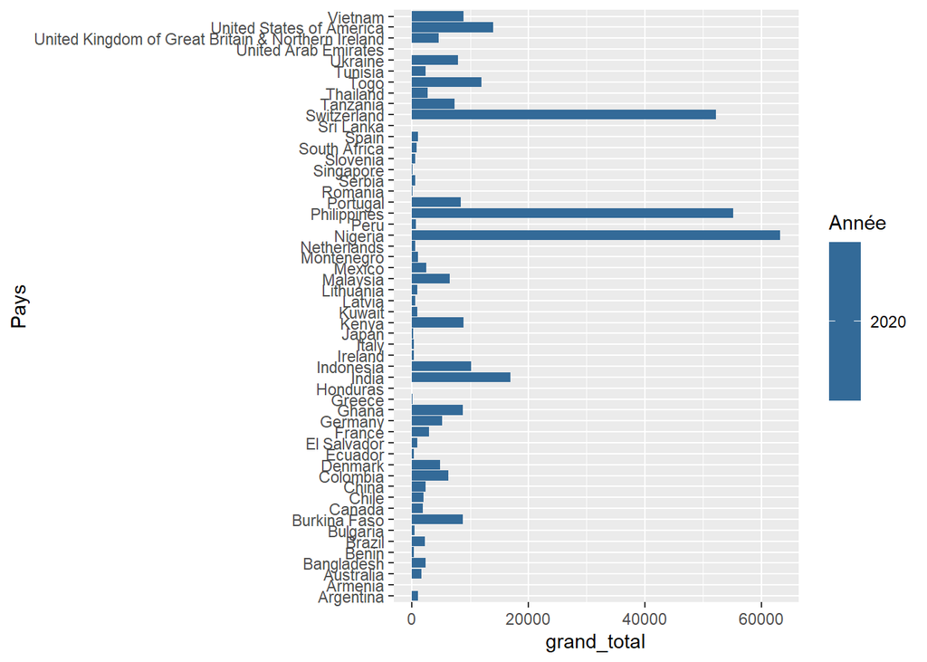

```r
plastique %>%
  filter(Année=="2020") %>%
  group_by(Pays) %>%
  ggplot()+
  aes(x= grand_total, y=Pays)+
  geom_bar(stat='identity', aes(fill= Année))
```

Groupement des pays par volontaires et nombre d’événements

```r
NBP<- plastique %>%
    as_tibble() %>%
    count(Pays,Année,Volontaires, Nombre_even)
```

Différentes sources de plastique .

```r
NBS<- plastique %>%
    as_tibble() %>%
    count(Source_plastic)
```

Quel est le pays avec le plus de volontaires ?

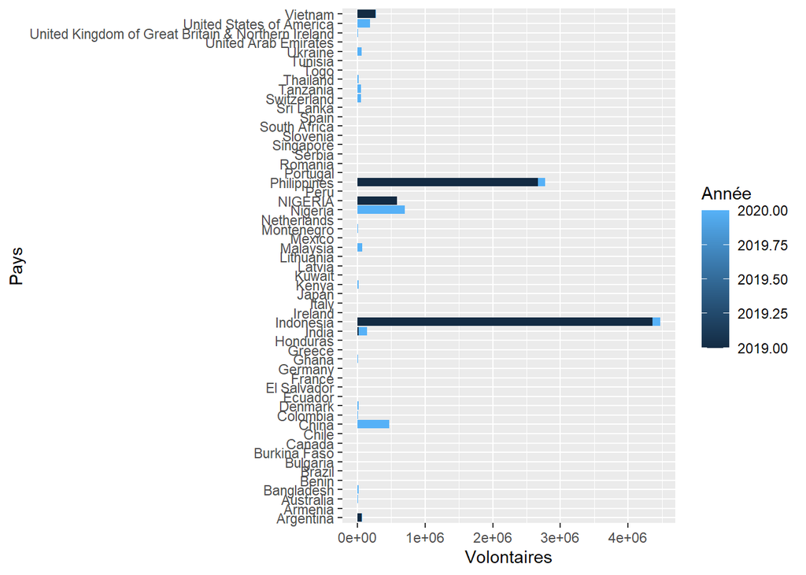

```r
plastique %>%
  group_by(Pays) %>%
ggplot()+
  aes(x= Volontaires ,y= Pays)+
  geom_bar(stat='identity', aes(fill=Année))
```